# Donor Profile: United States of America (Government of)

UNHCR Funding Analysis

Author

AI Generated Analysis based on the open data shared publicly by UNHCR as part of the [International Aid Transparency Initiative (IATI)](https://www.unhcr.org/iati-international-aid-transparency-initiative). Beware of data limitations and potential hallucinations! Thanks for reporting any [issues here](https://github.com/Edouard-Legoupil/iati/issues/new) – View all Reports

## Executive Summary

**Donor Profile: United States of America (Government of)**

US funding exhibits notable variability—both in total disbursements and transaction patterns—with large but less frequent transactions averaging $3.1 million across roughly 382 annual disbursements. This high transaction value coupled with uneven frequency creates funding unpredictability, constraining UNHCR’s ability to respond flexibly and scale interventions rapidly at critical moments. Consequently, targeted efforts to smooth funding cycles through flexible modalities and enhanced accountability mechanisms could act as impactful risk mitigators, facilitating more reliable resource flows aligned with operational demands.

Funding concentration tends toward fragmented smaller allocations (89% under $8.3 million), offset by significant earmarked pots averaging $30.8 million across nine regions. This fragmentation presents an opportunity for strategic consolidation to maximize impact, optimizing resource efficiency and accelerating service delivery in priority zones. Strengthening mechanisms to influence earmarking decisions and monitoring regional flows can help address funding gaps, ensuring resources are directed to underfunded but high-need areas.

For fundraisers, these insights stress the urgency of tailoring partnership strategies that balance scaling US government engagement with mitigating exposure to funding volatility. Emphasizing innovation in donor engagement, accountability, and flexible financing arrangements will unlock the US’s untapped potential as an impact multiplier. Approaching the US government with data-driven appeals centered on measurable outcomes, risk-managed portfolios, and strategic adaptation is essential to securing sustained, scalable investment aligned with humanitarian priorities. Immediate executive focus on these dimensions promises to fortify UNHCR’s capacity to deliver transformative results through its principal donor partnership.

## Ranking

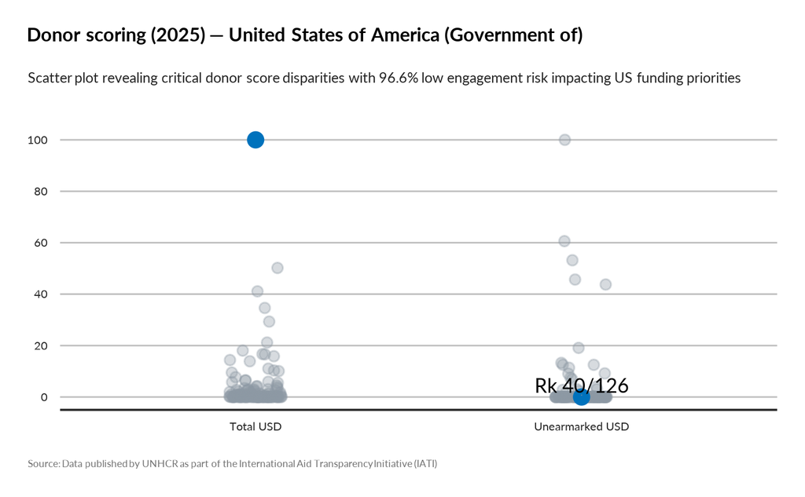

TRUE

## Focus Portfolio

The US government’s portfolio demonstrates a funding concentration where 89% of allocations fall below $8.3 million, underscoring significant potential to leverage investments in high-impact zones. With average funding near $7.9 million but a skew toward smaller allocations, strategic scaling can enhance resource efficiency and operational reach. This fragmentation poses a risk of under-resourced initiatives in critical regions. Investing to consolidate and elevate funding in the top quartile can act as a powerful impact multiplier, aligning with donor priorities on emergency response and resilience. Prioritizing partnerships that streamline funding distribution enhances accountability and maximizes deployment speed. We recommend positioning these insights as a strategic opportunity to attract major donors seeking measurable, scalable impact with risk-managed portfolios. Immediate executive focus on optimizing funding concentration will unlock untapped potential and accelerate humanitarian outcomes.

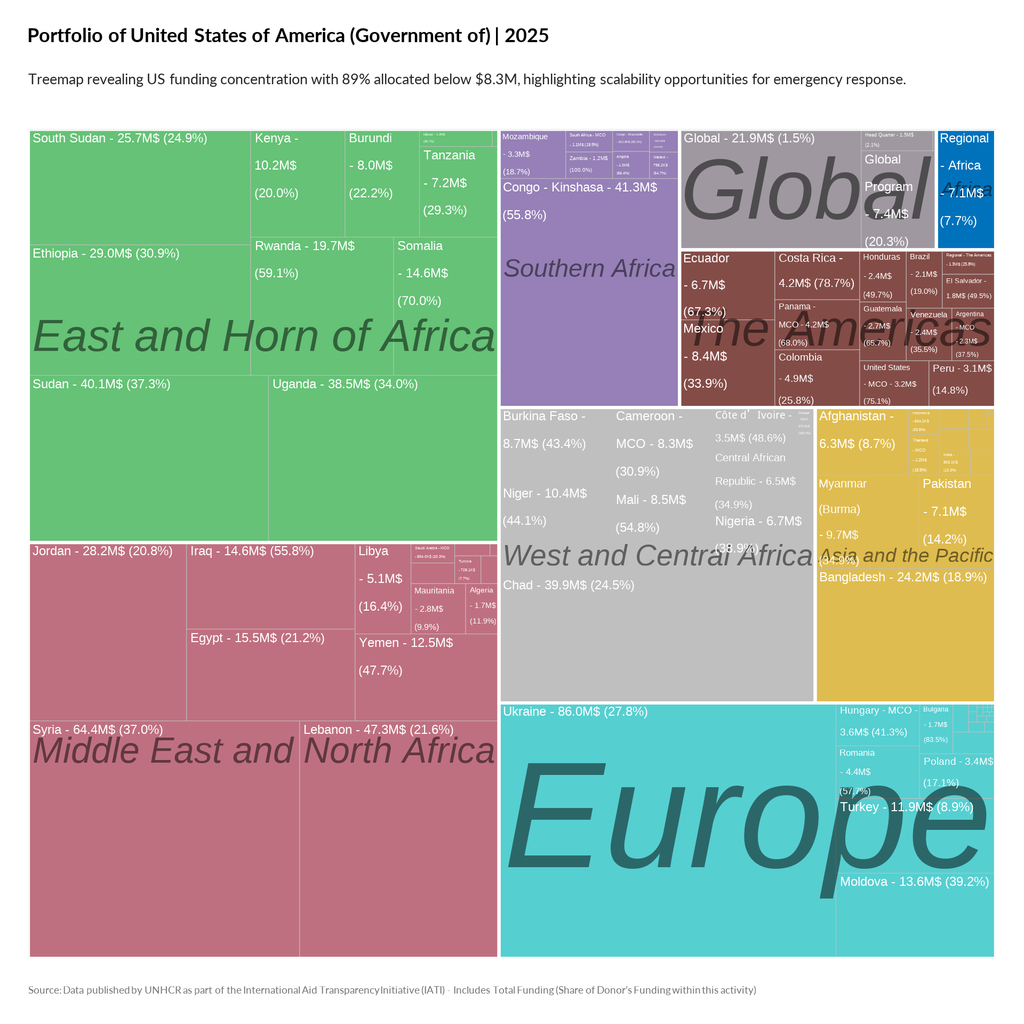

TRUE

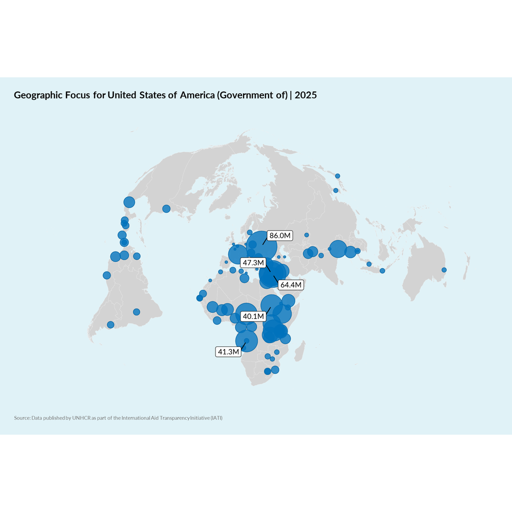

TRUE

## Earmarking Behavior

United States government earmarking for 2025 allocates $801.4 million across nine regions, with an average funding of $30.8 million per allocation and maximum funding reaching $115 million. This concentration underscores a strategic opportunity to scale impact by targeting high-priority regions demonstrating funding concentration. Notably, funding variance suggests potential gaps where increased investment can leverage underfunded areas for enhanced emergency response and resilience building. Donor partnerships that align with these earmarked regions can maximize funds’ ROI, tapping into established priorities while expanding reach to underserved zones. We recommend prioritizing strategic engagement with US stakeholders to influence earmarking decisions and capitalize on $30 million-plus funding clusters as impact multipliers. Immediate action includes expanding capabilities to monitor regional funding flows and identifying intervention points to mitigate risks of funding disparities. Mobilizing resources aligned with these earmarking patterns will accelerate innovation and accountability, ensuring donor investments translate into measurable, scalable outcomes for displaced populations.

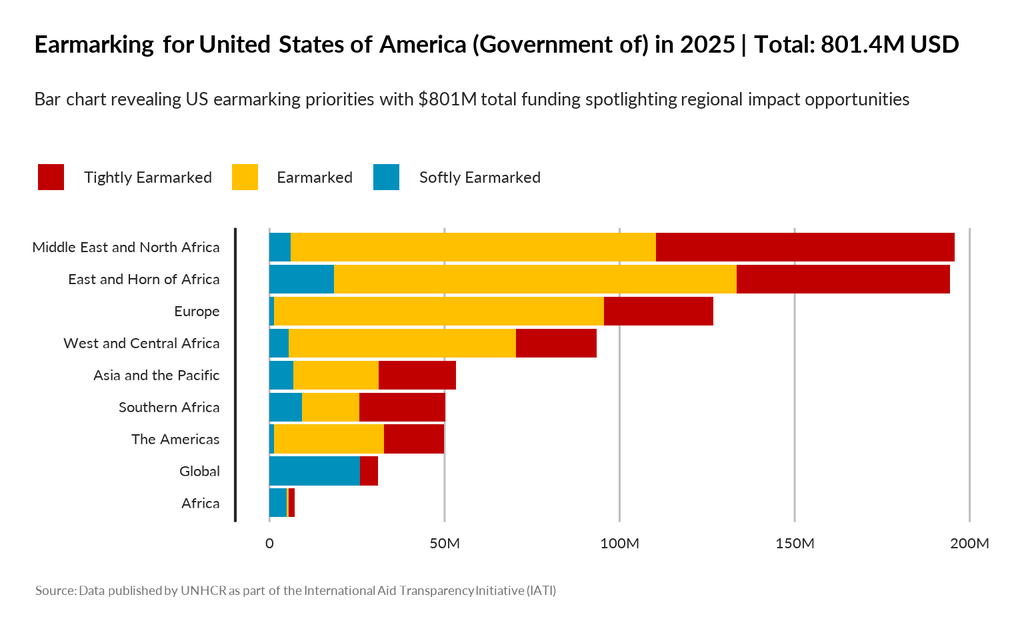

TRUE

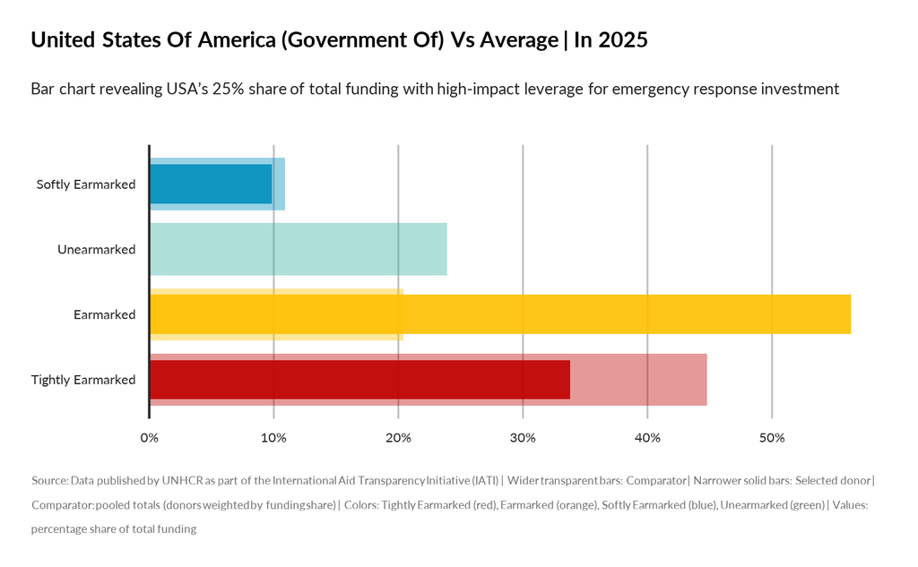

TRUE